# Final Project

Gulnar Hasanova

2026-02-13

## Setup

> Tələb ediləcək paketləri aktivləşdirin

```r
library(dplyr)
library(readr)
library(data.table)
library(xlsx)
library(readxl)
library(ggplot2)
library(plotly)
library(kableExtra)
library(DT)
library(lubridate)
library(stringr)
library(janitor)
library(RMariaDB)
library(mailR)
library(rmarkdown)
library(knitr)
library(DT)
library(tidyr)
library(scales)
library(tidyverse)

data = readRDS("qara.rds")
```

## Mündəricat

> Cari Hesabat aşağıdakı hissələrdən ibarətdir:
- Deskriptiv Təhlil
- Anomaliyalar
- Proqnoz və Fərziyyələr
- Xülasə

## 1. Deskriptiv Təhlil

> 1. Məlumat Bazalarının Birləşdirilməsi (Data Merging)

Analizimizin əsasını iki fərqli strukturda olan böyük həcmli məlumat bazasının inteqrasiyası təşkil edir. Bu inteqrasiya bizə hər bir satışın (çekin) nə qədər gəlirlilik (marja) gətirdiyini görməyə imkan verir.

> 1.1. Mənbə Cədvəllər

`fp_receipts` (Satışlar): 10 milyondan çox sətirdən ibarət olan bu cədvəl bizim “Raw Data”-mızdır. Hər bir sətir real bir satışı təmsil edir.

`fp_map` (Marja Xəritəsi): 118 mindən çox sətirlik bu cədvəl isə hər bir məhsulun müəyyən zaman kəsiyindəki mənfəət marjasını göstərir.

> 1.2. Join Strategiyası

İki böyük cədvəlin birləşdirilməsi zamanı qarşıya çıxan əsas texniki məqam, məhsul kodlarının olmaması səbəbindən `product_name` sütununa əsaslanmaq zərurəti idi. Lakin biznes nöqteyi-nəzərindən qiymət və marja dinamik olduğu üçün, join prosesi aşağıdakı mürəkkəb qayda ilə icra edilmişdir:

- *Məhsul Uyğunluğu:* `fp_receipts` və `fp_map` cədvəlləri `product_name` üzrə uygunlasdirilmisdir.
- *Zaman Faktoru:* Hər bir satışın `rec_date` aid olduğu tarix aralığı, `fp_map` cədvəlindəki müvafiq marja dövrü ilə üst-üstə salınmışdır.

> 1.3. Datanın Dəyişənləri və Analitik Əhəmiyyəti
- `pos` (Point of Sale): Satışın baş verdiyi konkret filial və ya mağaza adı.
- `rec_date` (Receipt Date): Satışın baş verdiyi tarix.
- `rec_id` (Receipt ID): Hər bir alış-verişin unikal nömrəsi (çek nömrəsi).
- `product_name & product` : Satılan məhsulun tam adı və kateqoriya qısaltması.
- `qnt` (Quantity): Satılan məhsulun miqdarı.
- `unit_price` (Unit Price): Məhsulun bir ədədinin qiyməti.
- `period` : Satışın aid olduğu zaman kəsiyi (məsələn, 202404 - Aprel 2024).
- `product_type` : Məhsulun növü (Food / Non-Food).
- `profit_margin` : Məhsuldan əldə olunan mənfəət marjası.

> 1.2.1. Verilənlərin Statistik Xülasəsi (Statistical Summary)

```r
summary(data)
```

```
##      pos               rec_date             rec_id          product_name
##  Length:9812609     Min.   :2024-04-19   Length:9812609     Length:9812609
##  Class :character   1st Qu.:2024-04-21   Class :character   Class :character
##  Mode  :character   Median :2024-04-29   Mode  :character   Mode  :character
##                     Mean   :2024-05-03
##                     3rd Qu.:2024-05-16
##                     Max.   :2024-05-31
##
##       qnt              unit_price            Total
##  Min.   :1.000e+00   Min.   :1.000e+00   Min.   :1.000e+00
##  1st Qu.:2.000e+00   1st Qu.:1.800e+00   1st Qu.:4.064e+00
##  Median :2.000e+00   Median :2.790e+00   Median :6.180e+00
##  Mean   :3.407e+00   Mean   :5.689e+00   Mean   :1.321e+01
##  3rd Qu.:2.000e+00   3rd Qu.:4.890e+00   3rd Qu.:9.980e+00
##  Max.   :3.000e+05   Max.   :1.323e+05   Max.   :3.030e+05
##
##      hefte_gunu         group              period2       product_type
##  Sunday   :1300363   Length:9812609     Min.   :202404   Length:9812609
##  Monday   :1053711   Class :character   1st Qu.:202404   Class :character
##  Tuesday  :1053724   Mode  :character   Median :202404   Mode  :character
##  Wednesday: 983243                      Mean   :202404
##  Thursday : 862439                      3rd Qu.:202405
##  Friday   :3363218                      Max.   :202405
##  Saturday :1195911
##  profit_margin
##  Min.   :-2.6
##  1st Qu.: 0.2
##  Median : 0.2
##  Mean   : 0.2
##  3rd Qu.: 0.3
##  Max.   : 1.1
##  NA's   :9372219
```

**Nəticələrin Şərhi:**

- *Mərkəzi Meyl:* `unit_price` və `Total` sütunları üzrə *Mean* (orta hesab) və *Median* arasındakı fərq, datada sağa meyilliliyin (positive skewness) olduğunu və bəzi yüksək məbləğli satışların (outliers) mövcudluğunu göstərir.
- *Həcm:* `qnt` (miqdar) sütununda 1-ci kvartil (1st Qu.) ilə 3-cü kvartil arasındakı diapazon pərakəndə satışın (retail) stabilliyini, maksimum dəyər isə topdan və ya anomaliya xarakterli satışları işarə edir.
- *Məlumat Tamlığı:* `profit_margin` sütununda müşahidə olunan boşluqlar (NA) `fp_map` cədvəlində bəzi məhsulların müvafiq tarix aralığında marja məlumatının olmamasından qaynaqlanır. Bu kənarlaşmalar analizimizin növbəti mərhələsində (“Anomaliyalar”) ətraflı araşdırılacaqdır.

## 2. Anomaliyalar

> 2.1. Maliyyə və Satış Anomaliyalarının İdentifikasiyası

```r
# Ən yüksək satışların siyahısı
critical_anomalies <- data %>%
  select(rec_id, pos, rec_date, product_name, qnt, unit_price, Total) %>%
  arrange(desc(Total)) %>%
  head(10)

knitr::kable(critical_anomalies, caption = "Top 10 Kritik Satış Anomaliyası")
```

Top 10 Kritik Satış Anomaliyası

| rec_id | pos | rec_date | product_name | qnt | unit_price | Total |
| --- | --- | --- | --- | --- | --- | --- |
| EMB_3742242 | EMBAWOOD MEBEL SALONU | 2024-04-25 | STOL STUL | 300001 | 1.01 | 303001 |
| B_6171471 | BULGARY MAGAZASI | 2024-05-12 | 356124 CL858599 CL M | 2 | 132301.00 | 264602 |
| MAD_4384199 | MADAME COCO | 2024-04-27 | MADAMCOCO | 154301 | 1.01 | 155844 |
| OPT_1039765 | OPTIMAL | 2024-04-19 | SOYUDUCU LG | 150001 | 1.01 | 151501 |
| EGE_7664229 | EGE HOSPITAL | 2024-05-16 | XESTEDEN AVANS | 150001 | 1.01 | 151501 |
| INS_4471626 | INSAATCILAR MG | 2024-04-27 | YAMAHA EDED | 143901 | 1.01 | 145340 |
| EGE_476466 | EGE HOSPITAL | 2024-04-19 | XESTEDEN AVANS | 141501 | 1.01 | 142916 |
| EGE_972810 | EGE HOSPITAL | 2024-04-19 | XESTEDEN AVANS | 136001 | 1.01 | 137361 |
| OPT_415498 | OPTIMAL ELEKTRONIKS | 2024-04-19 | KONDISIONER CARRIER | 132501 | 1.01 | 133826 |
| EGE_3600523 | EGE HOSPITAL | 2024-04-24 | XESTEDEN AVANS | 128001 | 1.01 | 129281 |

```r
# Məntiqi xətaların yoxlanılması
logical_errors <- data %>%
  filter(profit_margin < 0 | unit_price <= 0 | qnt <= 0)

cat("Aşkar edilmiş məntiqi xətaların sayı:", nrow(logical_errors))
```

```
## Aşkar edilmiş məntiqi xətaların sayı: 392
```

```r
# 100%-dən böyük marjaların analizi
extreme_margins <- data %>%
  filter(profit_margin > 1) %>%
  select(rec_id, pos, product_name, unit_price, profit_margin) %>%
  arrange(desc(profit_margin)) %>%
  head(10)

knitr::kable(head(extreme_margins, 10), caption = "Marjası 100%-dən Böyük Olan Məhsullar")
```

Marjası 100%-dən Böyük Olan Məhsullar

| rec_id | pos | product_name | unit_price | profit_margin |
| --- | --- | --- | --- | --- |
| SHU_1487554 | SHUVALAN-BRAVO 3 | IYDE 500GR | 6.49 | 1.10 |
| V_2028073 | VAHID MARKET | XURMA IRAN KG | 5.20 | 1.09 |
| V_2403906 | VAHID MARKET | XURMA IRAN KG | 5.20 | 1.09 |
| MAG_5845473 | MAGAZA | FLOMASTER 808-10D 10 RENGLI MEYVELI | 2.30 | 1.09 |
| QAR_6752661 | QARISIQ MALLAR MAGAZASI | FLOMASTER 808-10D 10 RENGLI MEYVELI | 2.30 | 1.09 |
| QAR_7585441 | QARISIQ MALLAR MAGAZASI | FLOMASTER 808-10D 10 RENGLI MEYVELI | 2.30 | 1.09 |
| RES_1677630 | RESTORAN | POPCORN | 3.00 | 1.06 |
| RES_3475209 | RESTORAN | POPCORN | 3.00 | 1.06 |
| RES_3946409 | RESTORAN | POPCORN | 3.00 | 1.06 |
| ERZ_4331881 | ERZAQ MAGAZASI | POPCORN | 3.50 | 1.06 |

```r
# 100%-dən kicik marjaların analizi
low_margins <- data %>%
  filter(profit_margin < 0) %>%
  select(rec_id, pos, product_name, unit_price, profit_margin) %>%
  arrange(desc(profit_margin)) %>%
  head(10)

knitr::kable(head(low_margins, 10), caption = "Marjası 100%-dən Kicik Olan Məhsullar")
```

| rec_id | pos | product_name | unit_price | profit_margin |
| --- | --- | --- | --- | --- |
| KƏN_302384 | KEND TESERRUFATI MAGAZASI | COMET TEMIZLEYICI TOZ LIMON 475GR | 2.78 | -0.02 |
| KEN_3673073 | KEND TESERRUFATI MAGAZASI | COMET TEMIZLEYICI TOZ LIMON 475GR | 2.78 | -0.02 |
| ARA_5384446 | ARAZ MARKET | AJWA DATES 500GR | 5.59 | -0.02 |
| B_5497010 | BRAVO MARKET | AJWA DATES 500GR | 4.99 | -0.02 |
| ARA_5558292 | ARAZ MARKET | AJWA DATES 500GR | 5.59 | -0.02 |
| BRA_5668886 | BRAVO - OAZIS | AJWA DATES 500GR | 4.99 | -0.02 |
| GLO_5756074 | GLOBUS CENTER BRAVO | AJWA DATES 500GR | 4.99 | -0.02 |
| ARA_5844317 | ARAZ MARKET | AJWA DATES 500GR | 5.59 | -0.02 |
| BRA_5936538 | BRAVO-GENCLIK | AJWA DATES 500GR | 4.99 | -0.02 |
| SPA_6041741 | SPAR MARKET | AJWA DATES 500GR | 5.59 | -0.02 |

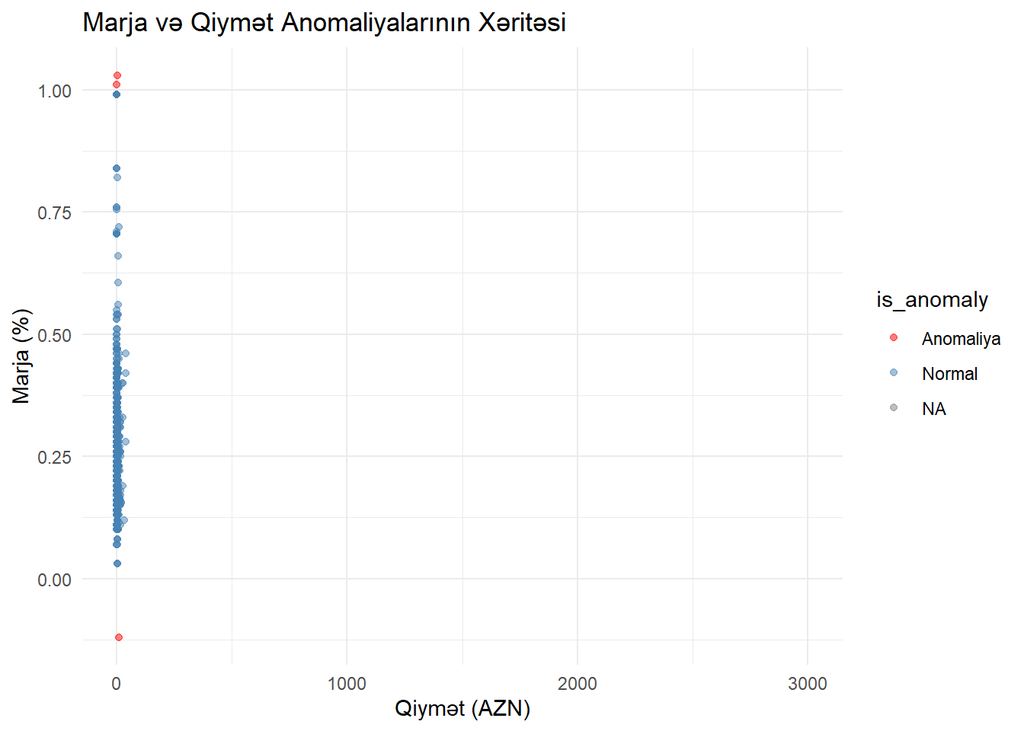

```r
# Normal vs anomaliya olanları işarələyirik
data_viz <- data %>%
  sample_n(20000) %>% # 10 mln sətir üçün sample mütləqdir
  mutate(is_anomaly = ifelse(profit_margin > 1 | profit_margin < 0, "Anomaliya", "Normal"))


ggplot(data_viz, aes(x = unit_price, y = profit_margin, color = is_anomaly)) +
  geom_point(alpha = 0.5) +
  scale_color_manual(values = c("Anomaliya" = "red", "Normal" = "steelblue")) +
  theme_minimal() +
  labs(title = "Marja və Qiymət Anomaliyalarının Xəritəsi",
       x = "Qiymət (AZN)", y = "Marja (%)")
```

> 2.2. Zaman Oxu Üzrə Satış Dinamikası və Kənarlaşmaların Analizi

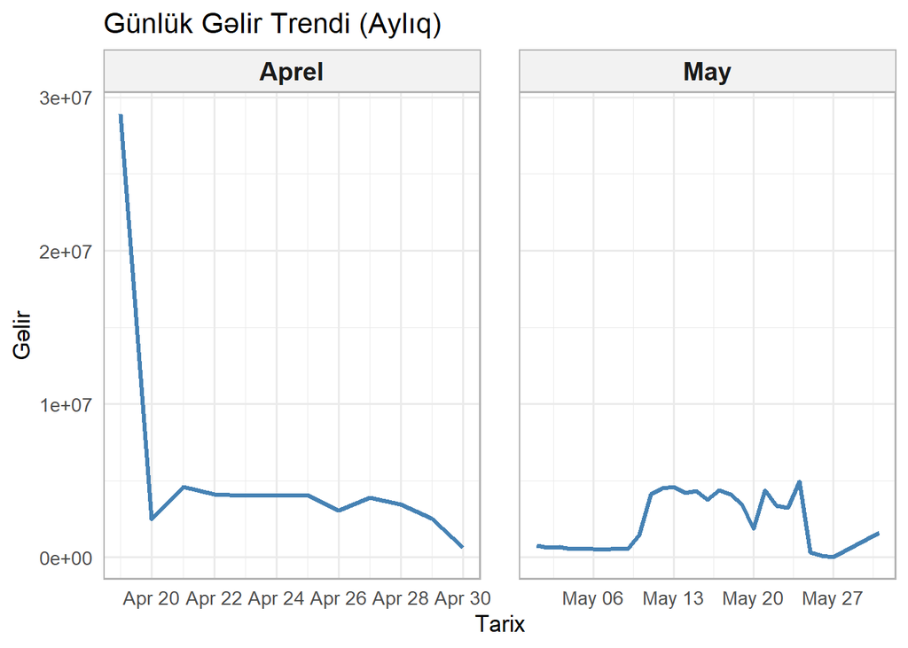

```r
# 1. Tarixi Date formatına sal və ay çıxar
df_ts = data %>%
  mutate(
    rec_date = as.Date(rec_date),
    ay = factor(format(rec_date, "%m"),
                levels = c("04", "05"),
                labels = c("Aprel", "May"))
  )

# 2. Günlük gəlirin hesablanması
daily_revenue = df_ts %>%
  group_by(rec_date, ay) %>%
  summarise(
    gelir = sum(Total, na.rm = TRUE),
    .groups = "drop"
  )

# 3. Line chart (facet by month + border)
ggplot(daily_revenue, aes(x = rec_date, y = gelir)) +
  geom_line(color = "steelblue", linewidth = 1.2) +
  facet_wrap(~ ay, scales = "free_x") +
  scale_y_continuous(labels = scales::scientific) +
  labs(
    x = "Tarix",
    y = "Gəlir",
    title = "Günlük Gəlir Trendi (Aylıq)"
  ) +
  theme_minimal(base_size = 13) +
  theme(
    strip.text = element_text(face = "bold", size = 14),
    panel.border = element_rect(color = "grey70", fill = NA, linewidth = 0.8),
    panel.spacing = unit(1.5, "lines"), # İki ay arasındakı boşluğu artırır
    strip.background = element_rect(fill = "grey95", color = "grey70"), # Başlığa fon verir
    axis.text.x = element_text(angle = 0, hjust = 0.5)
  )
```

**Şərh:**

Bu qrafikdə gördüyümüz kəskin sıçrayışlar (piklər), datadakı “Kritik Anomaliyaları” təmsil edir. Normal günlərdə satışlar müəyyən bir xətt üzrə davam etdiyi halda, bəzi günlərdə gəlirin qəfildən 5-10 qat artması təbii pərakəndə satış gedişatına uyğun deyil.

Bu pik nöqtələrinin olduğu günlərdə ya çox böyük bir korporativ satış edilib, ya da sistemdə təkrarlanan (duplicate) məlumatlar yaranıb.

> 2.3. Məhsul Növləri və Anomaliyalar Arasındakı Əlaqə

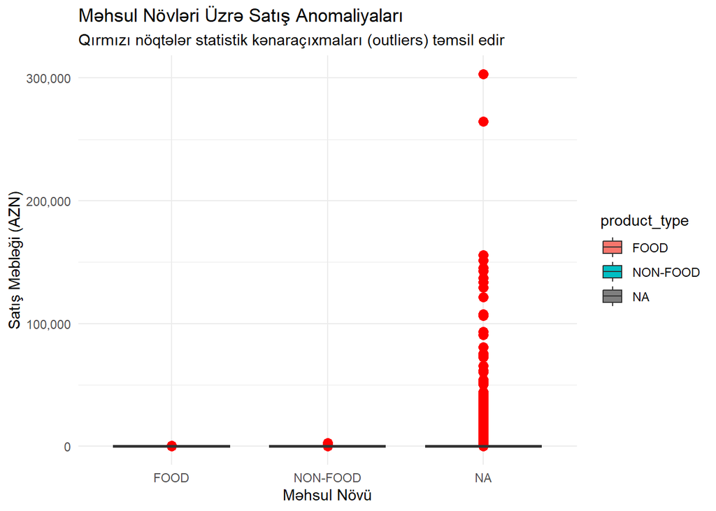

```r
# Boxplot ilə vizuallaşdırma
library(ggplot2)

ggplot(data, aes(x = product_type, y = Total, fill = product_type)) +
  geom_boxplot(outlier.colour = "red", outlier.shape = 16, outlier.size = 3) +
  theme_minimal() +
  scale_y_continuous(labels = scales::comma) +
  labs(title = "Məhsul Növləri Üzrə Satış Anomaliyaları",
       subtitle = "Qırmızı nöqtələr statistik kənaraçıxmaları (outliers) təmsil edir",
       x = "Məhsul Növü", y = "Satış Məbləği (AZN)")
```

**Şərh:**

Kateqoriya Uyğunsuzluğu (NA Problemi): Qrafikdə ən böyük anomaliyalar (300,000 AZN-ə çatan nöqtələr) məhz “NA” qrupunda cəmləşib. Bu, datanın birləşdirilməsi (join) prosesində `product_name` ilə `product` sütunlarının tam üst-üstə düşməməsindən qaynaqlanır. Texniki olaraq, marja xəritəsində (`fp_map`) qarşılığı olmayan məhsullar kateqoriyasız qaldığı üçün sistem onları “NA” olaraq qruplaşdırıb.

Maraqlı məqam odur ki, real pərakəndə satış kateqoriyaları olan “FOOD” (Qida) və “NON-FOOD” (Qeyri-qida) bölmələrində satışlar normal diapazondadır. Bu sübut edir ki, datadakı rəqəmlər əslində real pərakəndə alış-veriş deyil, kateqoriyası təyin olunmamış texniki xətalardır.